# Decentralization Impact on Provision of Health-related Services: Case of Benin

Giulia Minnucci,Daniel Jemberu, Rose-Camille Vincent

5 December 2014

# Project

Since the beginning of the 1990s, most developing countries have embarked in a process of subsequent decentralization, combining political, administrative and fiscal aspects. Decentralization has also been at the center stage of the international development agenda, being considered as a major mechanism for poverty reduction in low and middle-income countries. As part of this process, sub-national governments have been increasingly strengthened, and granted more power in terms decision-making regarding their communities.

In terms of provision of public goods, sub-national authorities are also taking the lead. For instance, provision of health-related public services have been decentralized in many countries such as Ghana, Zambia, Uganda. These initiatives have also been supported by bilateral and multilateral development agencies.

In this project, we focus on assessing the impact of decentralization on health provision. In order words, we try to assess whether granting more financial and administrative power to sub-national authorities result in a greater provision of basic health-related services such as access to water or healthcare centres.

**Research question**

*what impact does decentralization have on the provision of health-related services in Benin?*

**Why Benin?**

Benin is a french-speaking west-African country with a GDP/capita of US$ 804.67 in 2013 (5.6% growth in 2013) and an estimated population of 10.32 million habitants in 2013. The country is bordered by Nigeria on the east, Togo on the west, Burkina Faso and Niger on the North. The country is categorized as low-income and is currently ranked 165 out of 187 countries in the 2014 Human Development Index.

Benin is a young democracy. Since 2000, the country is embarked in a process of subsequent decentralization in 2000s which combines political, administrative and fiscal aspects. Legal provisions on the administrative and territorial reforms of 1999 created 77 municipalities and 12 departments and outlines competencies - ranging from tax raising power to local public expenditure (elementary schooling, health-related services, sanitation) - to be transferred from central to local governments. Although at its very early stage, was accompanied by a huge transformation of the political and administrative organization.

[figure not shown]

# Analytical Approach

The analysis is divided into two sections:

1. a macroeconomic overview of health-related expenditures and outcomes over the years 2005 to 2010.The datasets are drawn from the World Bank Indicators and the World Health Organization (WHO)
2. a microeconomic analysis which consists in an empirical assessment of the impact of decentralization on 4 health-related indicators which are access to water, access to toilet facilities, access to toilet facilities and access to healthcare centres. The analysis uses a combined unique dataset which combines indicators on municipal finances and health provision at the municipal level in Benin. The original datasets are obtained from the Ministry of Economy and Finances, the National Institute of Statistics and the National Commission on Local Finances, more particularly from the following surveys/census: Benin’s Integrated Modular Households Survey (EMICoV), the Demographic and Health Survey and the National Census.

## Macroeconomic overview

This section brings a general overview of health-related expenditures and outcome in Benin over the years 2005 to 2010. We’ve drawn data from the World Bank and WHO.

**World Bank Indicators**

The World Bank (WB) dataset includes the following indicators for Benin for the years 2005 to 2011.

1. health expenditure per capita: sum of public and private health expenditures as a ratio of total population. This indicator covers the provision of health services (preventive and curative), family planning activities, nutrition activities, and emergency aid designated for health but does not include provision of water and sanitation. Data are in current U.S. dollars.
2. public health expenditure: recurrent and capital spending from government (central and local) budgets, external borrowings and grants (including donations from international agencies and nongovernmental organizations), and social (or compulsory) health insurance funds.
3. improved sanitation facilities: access to improved sanitation facilities as the percentage of the population using improved sanitation facilities. This indicator includes flush/pour flush (to piped sewer system, septic tank, pit latrine), ventilated improved pit (VIP) latrine, pit latrine with slab, and composting toilet.

**World Health Organization Indicators**

The second dataset is taken from the WHO databases, particularly from the Global Health Observatory Data which provides information on health infrastructures per 100,000 population in Benin including:

1. Health posts, that are either community centres or health environments with a very limited number of beds with limited curative and preventive care resources normally assisted by health workers or nurses,
2. Health centers,which includes the number of health centres from the public and private sectors, per 100,000 population
3. Number of district/rural hospitals from the public and private sectors, per 100,000 population,
4. Number of provincial hospitals from the public and private sectors, per 100,000 population,
5. Number of specialized hospitals delivering mainly tertiary care from the public and private sectors, per 100,000 population. These specialized hospitals could be regional, specialized, research hospitals or Federal/National Institutes.
6. Number of specialized hospitals delivering mainly tertiary care from the public and private sectors, per 100,000 population. These specialized hospitals could be: regional, specialized, research hospitals or Federal/National Institutes.

Unlike the dataset from the World Bank, this datasets only provide Benin-related indicators for the years 2010 and 2013, which we extracted for this project.

|  | Indicator | Year | Display.Value |
| --- | --- | --- | --- |
| 68 | Total density per 100 000 population: Specialized hospitals | 2010 | 0.12 |
| 113 | Total density per 100 000 population: Provincial hospitals | 2013 | 0.05 |
| 135 | Total density per 100 000 population: Specialized hospitals | 2013 | 0.11 |
| 169 | Total density per 100 000 population: Health centres | 2010 | 6.36 |
| 209 | Total density per 100 000 population: Provincial hospitals | 2010 | 0.06 |
| 527 | Total density per 100 000 population: District/rural hospitals | 2010 | 0.29 |

Although the WHO data is only available for 2010 and 2013, this table indicates a small variation (decrease) in the number of provincial and specialized hospitals in Benin. As for the data from WHO, we will further assess these outcomes in the section below and with the microeconomic analysis.

## Microeconomic Analysis

In the second part of the analysis, we explore provision of health-related services and infrastructures on a local (municipal) level. Particularly, we look at the impact of decentralization on the access to basic health-related services and infrastructure.

**Independent variable: Decentralization**

Decentralization is our independent variable. It generally means the transfer of authority and power from higher to lower levels of governing, or from national to sub-national levels. Existing literature present various measurements methods for indicators that could proxy decentralization. In this project, and after an analysis of the context, we used the ratio of revenues over expenditure.

**Dependent variables**

We have decided to focus on four key variables which are: (i) access to water: defined as the percentage of households in the municipality that have access to water (ii)access to toilet facilities: percentage of households in the municipality that have access to toilet facilities (iii)water provision infrastructure: percentage of households in that municipality that are connected to SONEB (water pipeline) (iv) hospital: the number of existing hospitals or public healthcare centers in the municipality.

**Explanatory variables**

In addition to decentralization, we included a set of variables to account for heterogeneity across the municipalities. These are population, population density, per capita consumption, public expenditure per capita, households health consumption, indicators on monetary poverty, average literacy rate of the head of households, as well as a monetary poverty index. We assume that these variables might have some impact either on health health-related expenditures on municipal or households level, and also some impact on decentralization process per se.

### Results

**1.Effect of Decentralization on Water Access**

In this model, decentralization reveals to be insignificant: the range of specification is too wide for the variable to be significant. In regard to the other explanatory variables, on the other hand, only the Average Literacy rate of Head of Household is positively significant for a confidence interval of 5%. This indicates that the more educated are the heads of households in a municipality, the greater the propensity to have access to water. The channel of this impact is not particularly discussed in this project but it may have to do with the supply of labor force by more educated habitants which might result in higher income.

Our statistical test (gvlma) for the linear assumptions hold, however the value of the adjusted R square remains relatively low again implies potential mispecification and the omission of key variables.

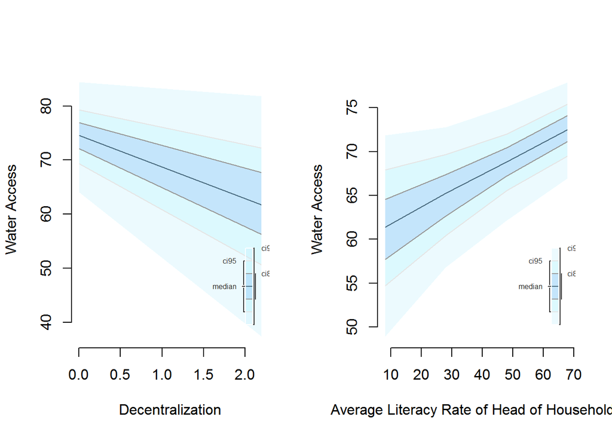

**2.Effect of decentralization on access to toilet facilities**

Alike the previous model on access to water, decentralization reveals insignificant (as seen by the range in the graph). For this model, average literacy rate of head of households is highly and positively significant (at 1%). Although the fitness test of the linear model assumptions hold in this case as well, the value of the adjusted R square remains relatively low which suggest potential mispecification.

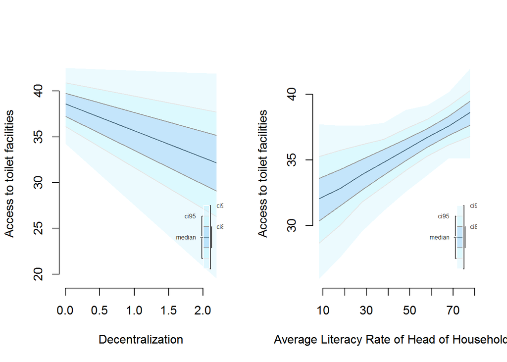

**3.Effect of decentralization on water pipeline connection**

In this model, our key explanatory variable ‘decentralization’ seems to have no impact of connection to water delivery infrastructure. In reverse, population density, households health consumption, and average literacy rate of heads of households reveal to be significant.

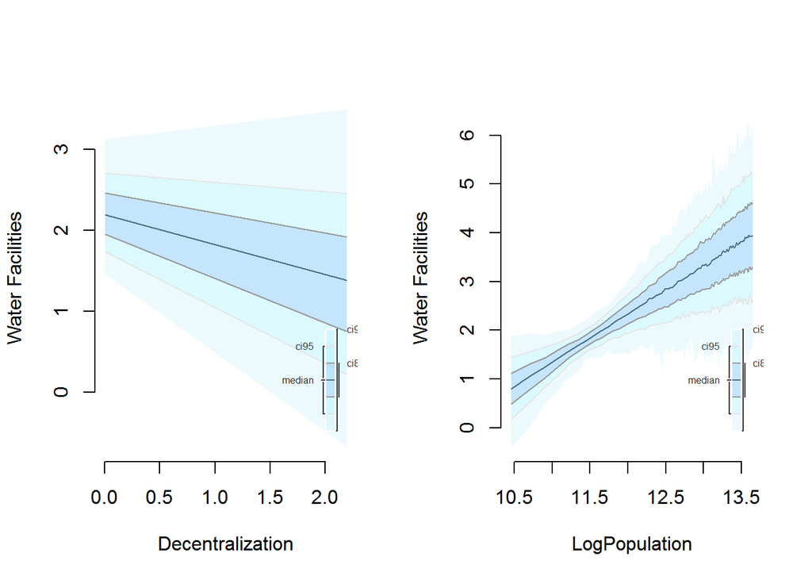

**4.Effect of decentralization on availability of public health infrastructure**

Like the previous models, decentralization does not seem to be a determinant of the availability of healthcare centers at the sub-national level. With regards to the explanatory variables: population, population density, and average literacy rate of the head of households seem to be strongly determinants of the existence of healthcare centers. Public expenditures per capita and poverty level result to be significant as well.

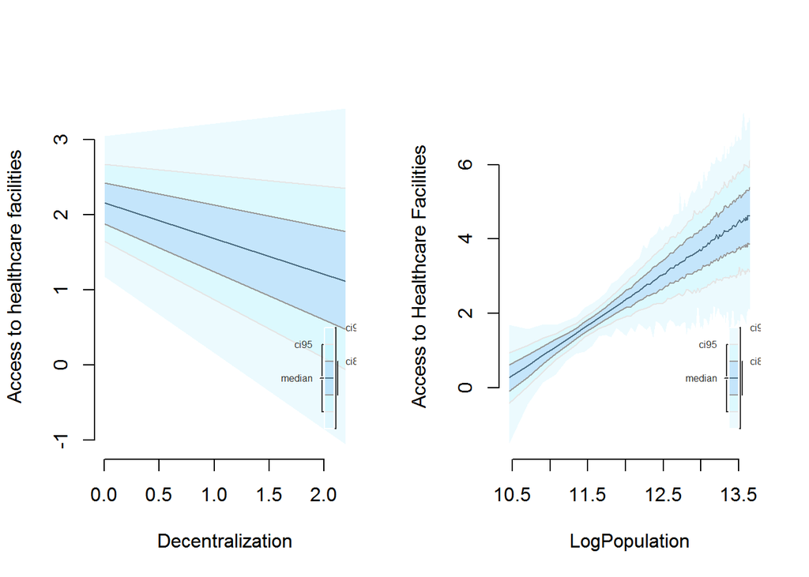

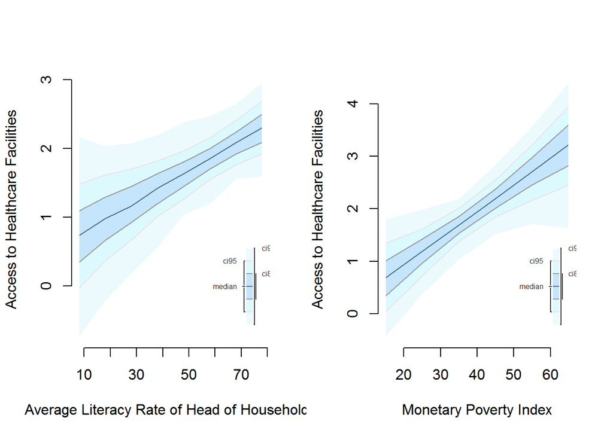

# Conclusions and Discussion

This project was an attempt to empirically assess the impact decentralization on provision of health-related facilities. Decentralization has been at the center stage of policy experiments in Benin which is the focus of this project. Health-related services have also been decentralized with the legal provisions on intergovernmental structure.

For this empirical assessment, we computed a proxy for decentralization as the ratio of own-revenue to total expenditures), and we assess the impact of this indicator on four dependent variables which are related to health. The overall result suggest that decentralization (proxied by our variable) does not have an impact of the provision of services considered in this paper (access to water, water facilities, toilet facilities and public healthcare centers).The overall result also suggests that average literacy rate of head of households, public expenditure per capita and demographic indicator such as population might have a significant impact of the provision of the above-mentioned services.

The scarcity of sub-national and local data, and the limitations to the empirical measurements of health provision or decentralization per se, have impeded a thorough analysis of the question. However, from a policy perspective, this exercise has indicated that education level of head of households might be an important component in the underlying process of rural development and that should be considered in the overall development policy of sub-national regions.

Moreover, the results suggest that, more than a decentralized system, an increase in the overall public expenditure per capita at municipal level might have some significant impact on health provision. Relying on these, we remain confident that this exercise will be a start for further reflection on the topic as it joins the global effort in the search of answers to key development questions.